# Problem Set 2

Author

Tiffany Wu

## Github Repo Link to Problem Set 2:

https://github.com/tiffany-wu/Stats506/tree/main/PS2

## Problem 1 - Dice Game

Let’s play a dice game. It costs $2 to play. You roll a single 6-sided die.

- On a roll of 3 or 5, you win twice your roll.
- On any other roll, you lose.

The input and output should be:

- Input: The number of dice to roll.
- Output: Total winnings

## a.

### Version 1: Loop

All the following functions take in 2 arguments: the number of rolls to simulate and the seed (optional and added for reproducibility in Part c). The output is the total winnings for the set number of rolls and the seed set.

```r
# Version 1: Using a loop

#' Play Dice Game - Loop Version
#'
#' This function simulates a dice game using a loop. It costs $2 to play each round,
#' and you roll a single 6-sided die. If the roll is 3 or 5, you win twice your roll;
#' otherwise, you lose $2.
#'
#' @param n Positive integer. The number of dice rolls (or rounds) to simulate.
#' @param seed Optional. Numeric. The seed for the random number generator.
#'
#' @return Numeric. The total winnings (or losses) after `n` rolls.
#'
#' @examples
#' play_dice_loop(10, seed = 123) # Example with 10 rolls with seed of 123
#'
play_dice_loop <- function(n, seed = NULL) {

  # Input sanitization -- make sure n is a positive integer
  # Double bars is logical OR operator, returns TRUE if at least one condition is TRUE
  if (!is.numeric(n) || n <= 0 || n != as.integer(n)) {
    stop("Error: 'n' must be a positive integer.")
  }

  # Input sanitization -- make sure if seed is provided it's numeric
  if (!is.null(seed) && !is.numeric(seed)) {
    stop("Error: 'seed' must be numeric.")
  }

  # Set seed if provided
  if (!is.null(seed)) {
    set.seed(seed)
  }

  # Initiate winnings with 0 dollars
  winnings <- 0

  for (i in 1:n) {

    # Roll a 6-sided die-- use sample instead of runif for whole values
    roll <- sample(1:6, 1, replace = TRUE)

    # If you get 3 or 5, you win twice your roll (minus the 2 it cost to play)
    if (roll == 3 || roll == 5) {
      winnings <- winnings + 2 * roll - 2
    } else {
      # Else you lose the 2 dollars it cost to play
      winnings <- winnings - 2
    }
  }
  return(winnings)
}

# Checking if it worked
play_dice_loop(3, seed = 5)
```

```
[1] 0
```

```r
play_dice_loop(30000)
```

```
[1] 20108
```

### Version 2: Vectorized

```r
#' Play Dice Game - Vectorized Version
#'
#' This function simulates a dice game using vectorized functions in R. It costs $2 to play each round,
#' and you roll a single 6-sided die. If the roll is 3 or 5, you win twice your roll;
#' otherwise, you lose $2.
#'
#' @param n Positive integer. The number of dice rolls (or rounds) to simulate.
#' @param seed Optional. Numeric. The seed for the random number generator.
#'
#' @return Numeric. The total winnings (or losses) after `n` rolls.
#'
#' @examples
#' play_dice_vector(10) # Example with 10 rolls
#'
play_dice_vector <- function(n, seed = NULL) {

  # Input sanitization -- make sure n is a positive integer
  if (!is.numeric(n) || n <= 0 || n != as.integer(n)) {
    stop("Error: 'n' must be a positive integer.")
  }

  # Input sanitization -- make sure seed is numeric if provided
  if (!is.null(seed) && !is.numeric(seed)) {
    stop("Error: 'seed' must be numeric.")
  }

  # Set seed if provided
  if (!is.null(seed)) {
    set.seed(seed)
  }

  # Roll n times using vectorized function
  rolls <- sample(1:6, n, replace = TRUE)

  # Calculate winnings: if roll is 3 or 5, you win twice your roll, otherwise lose $2
  winnings <- sum(ifelse(rolls == 3 | rolls == 5, 2 * rolls - 2, -2))

  return(winnings)
}

# Check if it works
play_dice_vector(3, seed = 89034892)
```

```
[1] -6
```

### Version 3: Table

```r
#' Play Dice Game - Table Version
#'
#' This function simulates a dice game by rolling all the dice at once and collapsing the die rolls into a table.
#' It costs $2 to play each round, and you roll a single 6-sided die. If the roll is 3 or 5, you win twice your roll;
#' otherwise, you lose $2.
#'
#' @param n Positive integer. The number of dice rolls (or rounds) to simulate.
#' @param seed Optional. Numeric. The seed for the random number generator.
#'
#' @return Numeric. The total winnings (or losses) after `n` rolls.
#'
#' @examples
#' play_dice_table(10) # Example with 10 rolls
#'
play_dice_table <- function(n, seed = NULL) {

  # Input sanitization -- make sure n is a positive integer
  if (!is.numeric(n) || n <= 0 || n != as.integer(n)) {
    stop("Error: 'n' must be a positive integer.")
  }

  # Input sanitization -- make sure seed is numeric if provided
  if (!is.null(seed) && !is.numeric(seed)) {
    stop("Error: 'seed' must be numeric.")
  }

  # Set seed if provided
  if (!is.null(seed)) {
    set.seed(seed)
  }

  # Roll n times and create a frequency table of results
  rolls <- sample(1:6, n, replace = TRUE)
 # print(rolls)
  roll_counts <-table(factor(rolls, levels = 1:6)) # Use factors to make sure all dice values appear in table (Source: ChatGPT, based on the hint to be careful indexing the table.)

  # Initialize winnings
  winnings <- 0

  # Calculate winnings for 3s and 5s-- adjust indexing safely
  winnings <- winnings + sum(roll_counts[c('3', '5')] * as.numeric(names(roll_counts[c('3', '5')])) * 2, na.rm = TRUE)

  # Subtract the cost of playing (2 dollars per roll) from total winnings
  winnings <- winnings - (sum(roll_counts[c('3', '5')]) * 2)

  # Calculate losses for other rolls
  winnings <- winnings - sum(roll_counts[c('1', '2', '4', '6')] * 2, na.rm = TRUE)

  return(winnings)
}

# Check that it works
play_dice_table(3)
```

```
[1] -6
```

### Version 4: apply function

```r
#' Play Dice Game - Apply Function Version
#'
#' This function simulates a dice game using an apply function. It costs $2 to play each round,
#' and you roll a single 6-sided die. If the roll is 3 or 5, you win twice your roll;
#' otherwise, you lose $2.
#'
#' @param n Positive integer. The number of dice rolls (or rounds) to simulate.
#' @param seed Optional. Numeric. The seed for the random number generator.
#'
#' @return Numeric. The total winnings (or losses) after `n` rolls.
#'
#' @examples
#' play_dice_apply(10) # Example with 10 rolls
#'
play_dice_apply <- function(n, seed = NULL) {

  # Input sanitization -- make sure n is a positive integer
  if (!is.numeric(n) || n <= 0 || n != as.integer(n)) {
    stop("Error: 'n' must be a positive integer.")
  }

  # Input sanitization -- make sure seed is numeric if provided
  if (!is.null(seed) && !is.numeric(seed)) {
    stop("Error: 'seed' must be numeric.")
  }

  # Set seed if provided
  if (!is.null(seed)) {
    set.seed(seed)
  }

  # Use sapply to roll the dice n times
  rolls <- sapply(1:n, function(x) sample(1:6, 1, replace = TRUE))

  # Calculate winnings using apply-like structure
  winnings <- sum(ifelse(rolls == 3 | rolls == 5, 2 * rolls - 2, -2))

  return(winnings)
}

# Check if it works
play_dice_apply(3)
```

```
[1] 4
```

## b. Demonstrate that all versions work. Do so by running each a few times, once with an input a 3, and once with an input of 3,000.

The output below demonstrates that all versions work, without setting the seed. This means that each output can be different.

```r
# Loop
play_dice_loop(3)
```

```
[1] -6
```

```r
play_dice_loop(3000)
```

```
[1] 2076
```

```r
# Table
play_dice_table(3)
```

```
[1] 14
```

```r
play_dice_table(3000)
```

```
[1] 1868
```

```r
# Vector
play_dice_vector(3)
```

```
[1] 0
```

```r
play_dice_vector(3000)
```

```
[1] 2020
```

```r
# Apply
play_dice_apply(3)
```

```
[1] 0
```

```r
play_dice_apply(3000)
```

```
[1] 2098
```

## c. Demonstrate that the four versions give the same result. Test with inputs 3 and 3,000. (You will need to add a way to control the randomization.)

The output below demonstrates that all versions work with the seed set to 285. As seen below, all versions have 14 dollars as the output for 3 rolls and 1896 dollars as the output for 3000 rolls.

```r
# Loop
play_dice_loop(3, seed = 285)
```

```
[1] 14
```

```r
play_dice_loop(3000, seed = 285)
```

```
[1] 1896
```

```r
# Table
play_dice_table(3, seed = 285)
```

```
[1] 14
```

```r
play_dice_table(3000, seed = 285)
```

```
[1] 1896
```

```r
# Vector
play_dice_vector(3, seed = 285)
```

```
[1] 14
```

```r
play_dice_vector(3000, seed = 285)
```

```
[1] 1896
```

```r
# Apply
play_dice_apply(3, seed = 285)
```

```
[1] 14
```

```r
play_dice_apply(3000, seed = 285)
```

```
[1] 1896
```

## d. Use the microbenchmark package to clearly demonstrate the speed of the implementations. Compare performance with a low input (1,000) and a large input (100,000). Discuss the results.

Based on the results of the microbenchmark package, we see that the vectorized function (Version 2) works best with both a high and low input and has the quickest speed. This makes sense because R is optimized for vectorized operations, and vectors eliminate the overhead of having to loop through things multiple times. The table function is second quickest and creates the tables by counting the frequency of each value in a vector, using vectorized functions like “sum”. While this involves sum overhead, such as having to convert data in factors, this is still relatively fast because R is optimized for counting operations. The apply and loop functions are the slowest because they have to loop over rows/columns or over each element in a vector, incurring a greater speed cost for each iteration. In general, in R, operations based on vector operations seem to be faster than those that have row-by-row, column-by-column, or element-by-element operations.

```r
library(microbenchmark)

# Set seed so that the microbenchmark numbers stay same for homework writeup
set.seed(2856)

# Run the microbenchmark comparison
benchmark_results <- microbenchmark(
  loop_1000 = play_dice_loop(1000, seed = 1000),
  vector_1000 = play_dice_vector(1000, seed = 1000),
  table_1000 = play_dice_table(1000, seed = 1000),
  apply_1000 = play_dice_apply(1000, seed = 1000),
  loop_100000 = play_dice_loop(100000, seed = 100000),
  vector_100000 = play_dice_vector(100000, seed = 100000),
  table_100000 = play_dice_table(100000, seed = 100000),
  apply_100000 = play_dice_apply(100000, seed = 100000),
  times = 10
)

# Print benchmark results
print(benchmark_results)
```

```
Unit: microseconds
          expr      min       lq       mean     median        uq       max
     loop_1000   6093.1   6516.2    9484.05    7703.50   12063.5   17788.9
   vector_1000    202.4    262.2     359.13     301.85     392.1     772.4
    table_1000    333.2    528.4     838.16     625.70    1324.9    1651.1
    apply_1000   7321.5   8200.3   10995.30    8835.55   13244.3   22590.8
   loop_100000 662369.6 745013.8  837526.55  817735.45  938853.4 1048870.3
 vector_100000  16939.8  18254.4   19035.80   19075.40   20101.9   21536.2
  table_100000  16709.0  17980.5   20106.70   19247.35   20612.0   27818.2
  apply_100000 894783.4 994109.9 1152676.24 1206332.35 1236932.5 1416584.9
 neval cld
    10 a
    10 a
    10 a
    10 a
    10  b
    10 a
    10 a
    10   c
```

## e. Do you think this is a fair game? Defend your decision with evidence based upon a Monte Carlo simulation.

Below, we write a function for a Monte Carlo simulation, called `simulate_games()`, to estimate the expected value of the game by running a large number of games (100000 games). Using the function `play_dice_vector()`, which was our quickest implementation of the game simulation, we roll the dice 100 times for each game, and run 100000 games. For each game, we calculate the winnings and then compute the average winnings across all the simulations. We then print out the average winnings and write an if/else statement to see whether the average winnings was favorable.

Based on the Monte Carlo simulation, our average winnings are 66.80 dollars, which is greater than 0 dollars, which means that *this is not a fair game and the player will, on average, win money.*

```r
#' Monte Carlo simulation to evaluate game fairness
#'
#' This function runs a dice game simulation a specified number of times
#' and returns the average winnings across all simulations.
#'
#' @param n_sim Integer. The number of simulations to run. For example, use 100,000 simulations for more robust results.
#'
#' @return Numeric. The average winnings across all simulations.
#'
#' @examples
#' simulate_game(100000)
#'
simulate_game <- function(n_sim) {

  # Replicate the game n_sim times
  winnings <- replicate(n_sim, play_dice_vector(100)) # Using vectorized version for speed, FIX the number of runs but don't set seed so we get different results each time

  # Get the average winnings from each simulation
  mean_winnings <- mean(winnings)

  return(mean_winnings)
}

# Simulate 100,000 games, setting seed for reproducibility
set.seed(285)
average_winnings <- simulate_game(100000)
print(average_winnings)
```

```
[1] 66.80442
```

```r
# Assess fairness
if (average_winnings < 0) {
  print("The game is not fair; on average, you lose money.")
} else if (average_winnings > 0) {
  print("The game is favorable; on average, you win money.")
} else {
  print("The game is fair; on average, you break even.")
}
```

```
[1] "The game is favorable; on average, you win money."
```

## Problem 2 - Linear Regression

Download the cars data set available at https://corgis-edu.github.io/corgis/csv/cars/. The goal is to examine the relationship between torque and highway gas mileage.

```r
# Load necessary libraries
library(readr)
library(tidyverse)
# Read in dataset
cars <- read_csv("cars.csv")
```

### a. The names of the variables in this data are way too long. Rename the columns of the data to more reasonable lengths.

```r
# What are the current names?
names(cars)
```

```
 [1] "Dimensions.Height"
 [2] "Dimensions.Length"
 [3] "Dimensions.Width"
 [4] "Engine Information.Driveline"
 [5] "Engine Information.Engine Type"
 [6] "Engine Information.Hybrid"
 [7] "Engine Information.Number of Forward Gears"
 [8] "Engine Information.Transmission"
 [9] "Fuel Information.City mpg"
[10] "Fuel Information.Fuel Type"
[11] "Fuel Information.Highway mpg"
[12] "Identification.Classification"
[13] "Identification.ID"
[14] "Identification.Make"
[15] "Identification.Model Year"
[16] "Identification.Year"
[17] "Engine Information.Engine Statistics.Horsepower"
[18] "Engine Information.Engine Statistics.Torque"
```

```r
# Rename columns to shorter, more readable names
cars2 <- cars %>%
  rename(
    height = "Dimensions.Height",
    length_dim = "Dimensions.Length", # Because length is also a command in R
    width = "Dimensions.Width",
    driveline = "Engine Information.Driveline",
    engine_type = "Engine Information.Engine Type",
    hybrid = "Engine Information.Hybrid",
    gears = "Engine Information.Number of Forward Gears",
    transmission = "Engine Information.Transmission",
    city_mpg = "Fuel Information.City mpg",
    fuel_type = "Fuel Information.Fuel Type",
    highway_mpg = "Fuel Information.Highway mpg",
    classification = "Identification.Classification",
    id = "Identification.ID",
    make = "Identification.Make",
    model_year = "Identification.Model Year",
    year = "Identification.Year",
    horsepower = "Engine Information.Engine Statistics.Horsepower",
    torque = "Engine Information.Engine Statistics.Torque"
  )
```

### b. Restrict the data to cars whose Fuel Type is “Gasoline”.

```r
# Filter
gasoline_cars <- cars2 %>%
  filter(fuel_type == "Gasoline")
```

### c. Examine the distribution of highway gas mileage. Consider whether a transformation could be used. If so, generate the transformed variable and use this variable going forward. If not, provide a short justification.

Based on the histogram and boxplot below, we can see that the data is severely right-skewed. Usually, to deal with skewness, we can employ a log transformation for the outlier, which will make the distribution more normally distributed. However, upon further inspection of the values making the distribution skewed, we see that one car has an mpg of 223, which is 181 mpg more than the next highest mpg and also not possible in today’s world. Given that 223 mpg is an impossible value for a car, we opt to get rid of this outlier rather than generating a transformed variable moving forward. We do this because a transformation of the variable would not fix the underlying problem that 223 mpg is impossible.

After we get rid of the outlier, we plot the histogram and examine the skewness again. This time, we see that the plot looks more normally distributed, and the highway mpg variable has a skewness of 0.46 (which is between the acceptable values of -1 and +1) and a kurtosis of -0.27 (which is between the generally acceptable values of between -2 and +2 for a normal distribution). Therefore, we stick to our decision of just deleting the outlier and not making any transformations.

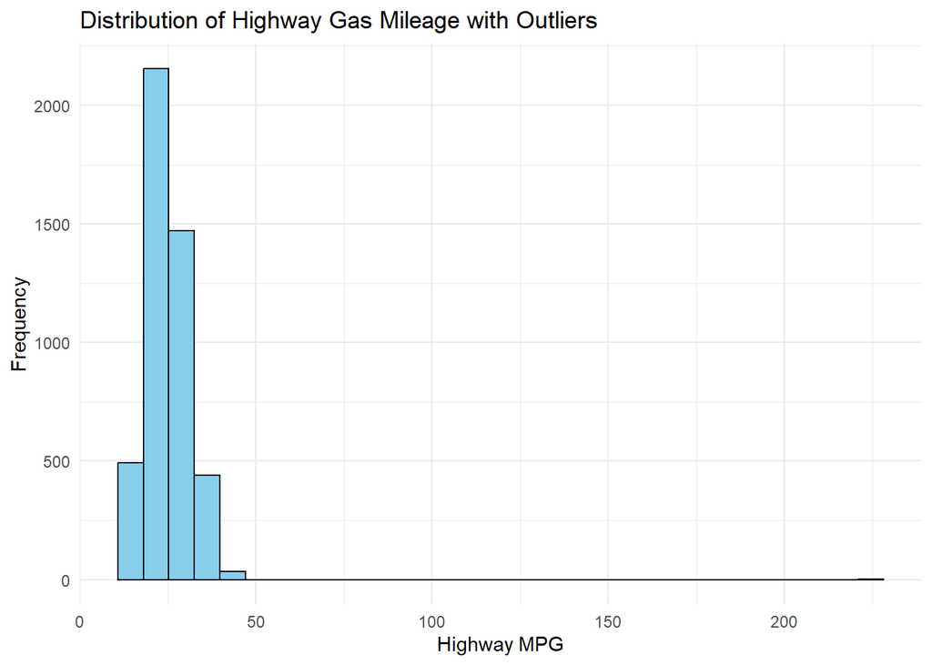

```r
# Examine distribution using histogram and boxplot

ggplot(gasoline_cars, aes(x = highway_mpg)) +
  geom_histogram(bins = 30, color = "black", fill = "skyblue") +
  labs(
    title = "Distribution of Highway Gas Mileage with Outliers",
    x = "Highway MPG",
    y = "Frequency"
  ) +
  theme_minimal()
```

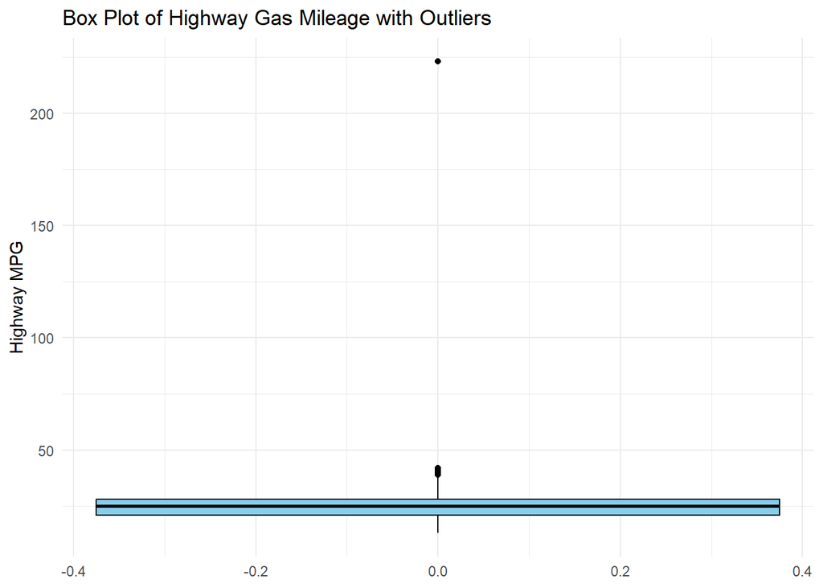

```r
ggplot(gasoline_cars, aes(y = highway_mpg)) +
  geom_boxplot(fill = "skyblue", color = "black") +
  labs(
    title = "Box Plot of Highway Gas Mileage with Outliers",
    y = "Highway MPG"
  ) +
  theme_minimal()
```

```r
# What is the max? This is an outlier
summary(gasoline_cars$highway_mpg) # 223
```

```
   Min. 1st Qu.  Median    Mean 3rd Qu.    Max.
  13.00   21.00   25.00   24.97   28.00  223.00
```

```r
# Get skewness/kurtosis
library(psych)
psych::describe(gasoline_cars$highway_mpg)
```

```
   vars    n  mean   sd median trimmed  mad min max range skew kurtosis   se
X1    1 4591 24.97 6.03     25   24.62 5.93  13 223   210 7.99   251.36 0.09
```

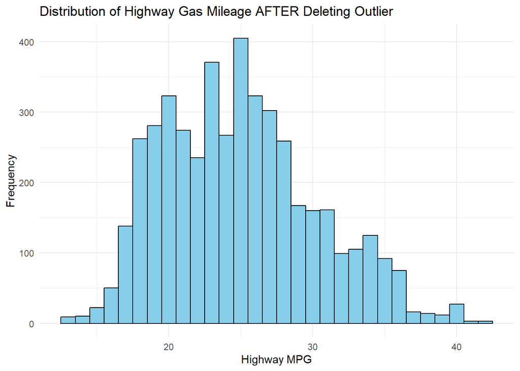

```r
# If we get rid of the outlier, it's better.
gasoline_cars2 <- gasoline_cars %>% filter(highway_mpg <100)

# Replot histogram to see if things get more normal
ggplot(gasoline_cars2, aes(x = highway_mpg)) +
  geom_histogram(bins = 30, color = "black", fill = "skyblue") +
  labs(
    title = "Distribution of Highway Gas Mileage AFTER Deleting Outlier",
    x = "Highway MPG",
    y = "Frequency"
  ) +
  theme_minimal()
```

```r
# See the descriptives again to check skewness/kurtosis numbers
psych::describe(gasoline_cars2$highway_mpg) # if get rid of outlier, skewness is now <1, at 0.46
```

```
   vars    n  mean   sd median trimmed  mad min max range skew kurtosis   se
X1    1 4590 24.92 5.28     25   24.62 5.93  13  42    29 0.46    -0.27 0.08
```

### d. Fit a linear regression model predicting MPG on the highway. The predictor of interest is torque. Control for:

- The horsepower of the engine
- All three dimensions of the car
- The year the car was released, as a categorical variable.

### Briefly discuss the estimated relationship between torque and highway MPG. Be precise about the interpretation of the estimated coefficient.

Based on the regression results below, we see that a one-unit (I think the unit would be in Newton-meters, based on a Google search, but I’m not an expert in cars) increase in torque is associated with a *0.052 decrease* in highway MPG, on average. This association is statistically significant at the p<0.05 level, even after controlling for horsepower, dimensions of the car, and the year the car was released. The negative relationship between torque and highway MPG makes sense since higher torque often means a more powerful engine, which can consume more fuel.

```r
library(lmtest)
# Make year a categorical variable
gasoline_cars2 <- gasoline_cars2 %>%
  mutate(year = as.factor(year))

# Regression
reg1 <- lm(highway_mpg ~ torque + horsepower + height + length_dim + width + year,
                   data = gasoline_cars2)

summary(reg1)
```

```
Call:
lm(formula = highway_mpg ~ torque + horsepower + height + length_dim +
    width + year, data = gasoline_cars2)

Residuals:
     Min       1Q   Median       3Q      Max
-10.9695  -2.4981  -0.3671   2.4164  19.8079

Coefficients:
              Estimate Std. Error t value Pr(>|t|)
(Intercept) 32.4107371  0.5486291  59.076   <2e-16 ***
torque      -0.0517480  0.0016727 -30.937   <2e-16 ***
horsepower   0.0171254  0.0017290   9.905   <2e-16 ***
height       0.0104613  0.0008555  12.228   <2e-16 ***
length_dim   0.0011433  0.0006710   1.704   0.0885 .
width       -0.0008147  0.0006867  -1.186   0.2356
year2010    -0.4497677  0.5138721  -0.875   0.3815
year2011     0.0709912  0.5130245   0.138   0.8899
year2012     1.2925749  0.5170481   2.500   0.0125 *
---
Signif. codes:  0 '***' 0.001 '**' 0.01 '*' 0.05 '.' 0.1 ' ' 1

Residual standard error: 3.494 on 4581 degrees of freedom
Multiple R-squared:  0.5626,    Adjusted R-squared:  0.5618
F-statistic: 736.5 on 8 and 4581 DF,  p-value: < 2.2e-16
```

### e. It seems reasonable that there may be an interaction between torque and horsepower. Refit the model (with lm) and generate an interaction plot, showing how the relationship between torque and MPG changes as horsepower changes. Choose reasonable values of torque, and show lines for three different reasonable values of horsepower.

First, we refit the model with the interaction. In the regression output, we see that the effect of torque on highway MPG varies statistically significantly depending on the level of horsepower. At low levels of horsepower, the negative association of torque with highway MPG is stronger; as horsepower increases, the negative association of torque with highway MPG decreases (the interaction term is positive). This means there is a statistically significant moderation between the two terms.

```r
library(emmeans)
# Refit model with interaction
interaction_model <- lm(highway_mpg ~ torque * horsepower + height + length_dim + width + year,
                        data = gasoline_cars2)

summary(interaction_model)
```

```
Call:
lm(formula = highway_mpg ~ torque * horsepower + height + length_dim +
    width + year, data = gasoline_cars2)

Residuals:
     Min       1Q   Median       3Q      Max
-11.2605  -2.2128  -0.2145   2.0901  21.6514

Coefficients:
                    Estimate Std. Error t value Pr(>|t|)
(Intercept)        4.247e+01  5.706e-01  74.436  < 2e-16 ***
torque            -8.766e-02  1.823e-03 -48.090  < 2e-16 ***
horsepower        -1.644e-02  1.827e-03  -9.000  < 2e-16 ***
height             7.061e-03  7.696e-04   9.175  < 2e-16 ***
length_dim         1.189e-03  5.985e-04   1.987  0.04700 *
width             -1.666e-03  6.131e-04  -2.717  0.00661 **
year2010          -5.604e-01  4.584e-01  -1.222  0.22162
year2011          -2.967e-02  4.577e-01  -0.065  0.94832
year2012           1.185e+00  4.613e-01   2.569  0.01024 *
torque:horsepower  1.142e-04  3.330e-06  34.301  < 2e-16 ***
---
Signif. codes:  0 '***' 0.001 '**' 0.01 '*' 0.05 '.' 0.1 ' ' 1

Residual standard error: 3.117 on 4580 degrees of freedom
Multiple R-squared:  0.652, Adjusted R-squared:  0.6513
F-statistic: 953.3 on 9 and 4580 DF,  p-value: < 2.2e-16
```

Then, we generate the interaction plot. We see that torque ranges from 98 to 774, so we choose values of torque between 90 and 790, going up by 20. For our three values of horsepower, we choose the 25th, 50th, and 75th percentiles of horsepower to give as a good range for low, median, and high levels of horsepower. This graph visually shows us the moderation of horsepower on torque that we saw in the regression output above.

For cars with low horsepower, increasing torque is more likely to reduce highway MPG. For cars with higher horsepower, increasing torque still reduces highway MPG, but the rate is less negative. This suggests that cars with stronger horsepower are better able to handle higher torque without compromising fuel efficiency as much.

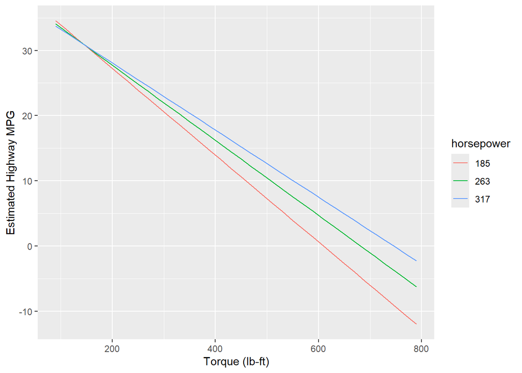

```r
# Use `emmeans` to calculate estimated marginal means for the interaction between torque and horsepower
library(emmeans)

# Choose reasonable values for torque and specify three values of horsepower for the plot
torque_values <- seq(90, 790, by = 20)

# Horsepower values based on quantiles.
horsepower_values <- quantile(gasoline_cars2$horsepower, probs = c(0.25, 0.5, 0.75), na.rm = TRUE)

# Generate the estimated marginal means
em_interaction <- emmeans(interaction_model, ~ torque * horsepower,
                          at = list(torque = torque_values, horsepower = horsepower_values))

# Plot the interaction effect using `emmip()`
emmip(em_interaction, horsepower ~ torque,
      at = list(torque = torque_values, horsepower = horsepower_values),
      xlab = "Torque (lb-ft)",
      ylab = "Estimated Highway MPG",
      lines = TRUE)
```

```r
gc_2009 <- gasoline_cars2 %>% filter(year == 2009)
gc_2012 <- gasoline_cars2 %>% filter(year == 2012)

# Refit model with interaction for 2009
interaction_model_2009 <- lm(highway_mpg ~ torque * horsepower + height + length_dim + width,
                        data = gc_2009)

summary(interaction_model)
```

```
Call:
lm(formula = highway_mpg ~ torque * horsepower + height + length_dim +
    width + year, data = gasoline_cars2)

Residuals:
     Min       1Q   Median       3Q      Max
-11.2605  -2.2128  -0.2145   2.0901  21.6514

Coefficients:
                    Estimate Std. Error t value Pr(>|t|)
(Intercept)        4.247e+01  5.706e-01  74.436  < 2e-16 ***
torque            -8.766e-02  1.823e-03 -48.090  < 2e-16 ***
horsepower        -1.644e-02  1.827e-03  -9.000  < 2e-16 ***
height             7.061e-03  7.696e-04   9.175  < 2e-16 ***
length_dim         1.189e-03  5.985e-04   1.987  0.04700 *
width             -1.666e-03  6.131e-04  -2.717  0.00661 **
year2010          -5.604e-01  4.584e-01  -1.222  0.22162
year2011          -2.967e-02  4.577e-01  -0.065  0.94832
year2012           1.185e+00  4.613e-01   2.569  0.01024 *
torque:horsepower  1.142e-04  3.330e-06  34.301  < 2e-16 ***
---
Signif. codes:  0 '***' 0.001 '**' 0.01 '*' 0.05 '.' 0.1 ' ' 1

Residual standard error: 3.117 on 4580 degrees of freedom
Multiple R-squared:  0.652, Adjusted R-squared:  0.6513
F-statistic: 953.3 on 9 and 4580 DF,  p-value: < 2.2e-16
```

```r
# Refit model with interaction for 2012
interaction_model_2012 <- lm(highway_mpg ~ torque * horsepower + height + length_dim + width,
                        data = gc_2012)

summary(interaction_model)
```

```
Call:
lm(formula = highway_mpg ~ torque * horsepower + height + length_dim +
    width + year, data = gasoline_cars2)

Residuals:
     Min       1Q   Median       3Q      Max
-11.2605  -2.2128  -0.2145   2.0901  21.6514

Coefficients:
                    Estimate Std. Error t value Pr(>|t|)
(Intercept)        4.247e+01  5.706e-01  74.436  < 2e-16 ***
torque            -8.766e-02  1.823e-03 -48.090  < 2e-16 ***
horsepower        -1.644e-02  1.827e-03  -9.000  < 2e-16 ***
height             7.061e-03  7.696e-04   9.175  < 2e-16 ***
length_dim         1.189e-03  5.985e-04   1.987  0.04700 *
width             -1.666e-03  6.131e-04  -2.717  0.00661 **
year2010          -5.604e-01  4.584e-01  -1.222  0.22162
year2011          -2.967e-02  4.577e-01  -0.065  0.94832
year2012           1.185e+00  4.613e-01   2.569  0.01024 *
torque:horsepower  1.142e-04  3.330e-06  34.301  < 2e-16 ***
---
Signif. codes:  0 '***' 0.001 '**' 0.01 '*' 0.05 '.' 0.1 ' ' 1

Residual standard error: 3.117 on 4580 degrees of freedom
Multiple R-squared:  0.652, Adjusted R-squared:  0.6513
F-statistic: 953.3 on 9 and 4580 DF,  p-value: < 2.2e-16
```

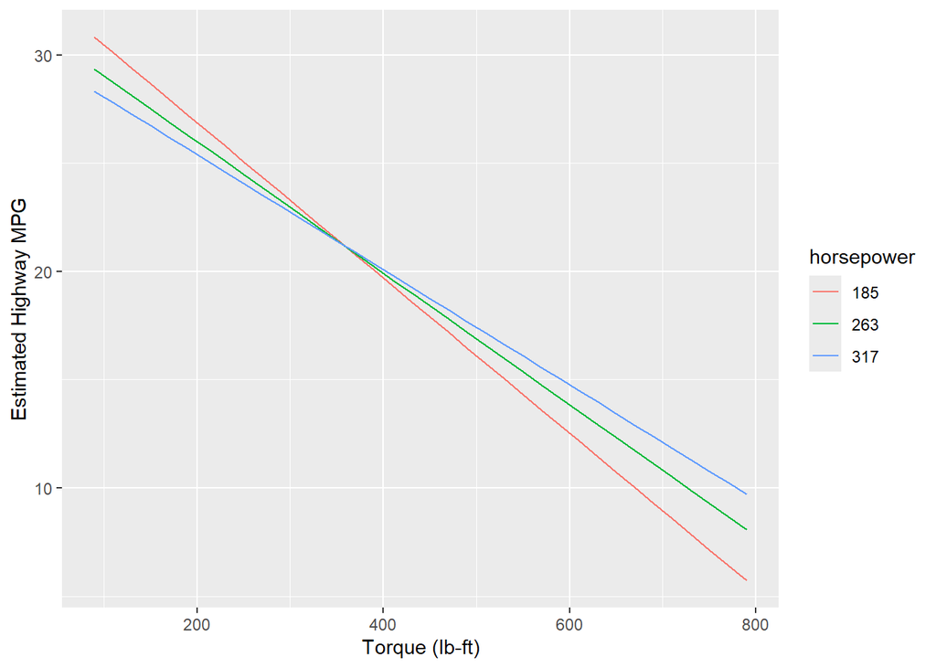

```r
# Generate the estimated marginal means for 2009 and 2012
em_interaction_2009 <- emmeans(interaction_model_2009, ~ torque * horsepower,
                          at = list(torque = torque_values, horsepower = horsepower_values))

em_interaction_2012 <- emmeans(interaction_model_2012, ~ torque * horsepower,
                          at = list(torque = torque_values, horsepower = horsepower_values))


# Plot the interaction effect using `emmip()` for 2009
emmip(em_interaction_2009, horsepower ~ torque,
      at = list(torque = torque_values, horsepower = horsepower_values),
      xlab = "Torque (lb-ft)",
      ylab = "Estimated Highway MPG",
      lines = TRUE)
```

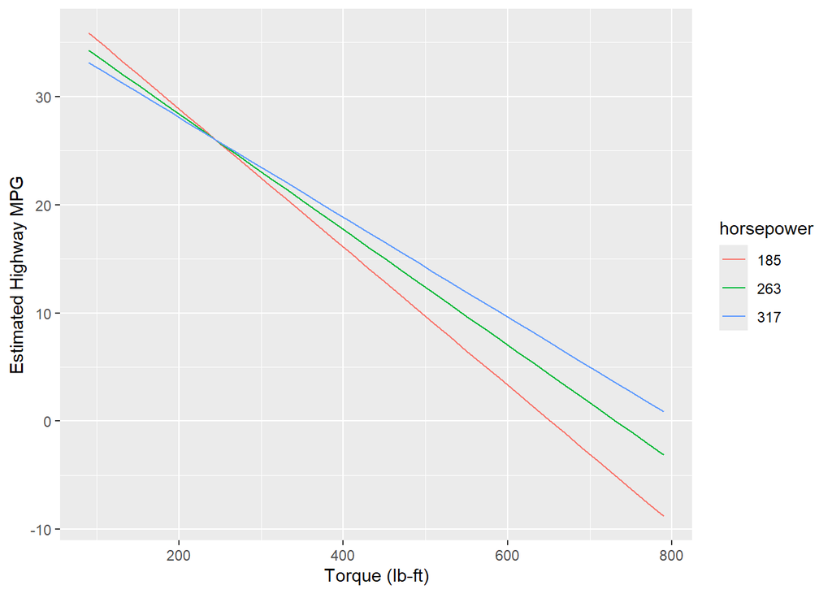

```r
# Plot the interaction effect using `emmip()` for 2012
emmip(em_interaction_2012, horsepower ~ torque,
      at = list(torque = torque_values, horsepower = horsepower_values),
      xlab = "Torque (lb-ft)",
      ylab = "Estimated Highway MPG",
      lines = TRUE)
```

### f. Calculate from d. manually (without using lm) by first creating a proper design matrix, then using matrix algebra to estimate. Confirm that you get the same result as lm did prior.

We get the -0.0517480111 coefficient for torque, along with all the same other coefficients, using both `lm()` and matrix algebra.

```r
# Get the design matrix

head(model.matrix(highway_mpg ~ torque + horsepower + height + length_dim + width + year, data = gasoline_cars2))
```

```
  (Intercept) torque horsepower height length_dim width year2010 year2011
1           1    236        250    140        143   202        0        0
2           1    207        200    140        143   202        0        0
3           1    207        200    140        143   202        0        0
4           1    207        200    140        143   202        0        0
5           1    207        200    140        143   202        0        0
6           1    243        265     91         17    62        0        0
  year2012
1        0
2        0
3        0
4        0
5        0
6        0
```

```r
cars_mat <- model.matrix(highway_mpg ~ torque + horsepower + height + length_dim + width + year, data = gasoline_cars2)

# Rename the model matrix to be X for the matrix algebra
X_mat <- cars_mat

# y matrix
y_mat <- gasoline_cars2$highway_mpg

# Check the dimensions to ensure compatibility
cat("Dimensions of X_mat:", dim(X_mat), "\n")
```

```
Dimensions of X_mat: 4590 9
```

```r
cat("Length of y_mat:", length(y_mat), "\n")
```

```
Length of y_mat: 4590
```

```r
# Matrix algebra
# Manually calculate the regression coefficients using matrix algebra
# Formula: beta_hat = (X'X)^(-1) X'y
beta_hat <- solve(t(X_mat) %*% X_mat) %*% t(X_mat) %*% y_mat

print(beta_hat)
```

```
                     [,1]
(Intercept) 32.4107371447
torque      -0.0517480111
horsepower   0.0171253987
height       0.0104613453
length_dim   0.0011433004
width       -0.0008146917
year2010    -0.4497677480
year2011     0.0709911939
year2012     1.2925748832
```

```r
# Check against regression
coefficients(reg1)
```

```
  (Intercept)        torque    horsepower        height    length_dim
32.4107371447 -0.0517480111  0.0171253987  0.0104613453  0.0011433004
        width      year2010      year2011      year2012
-0.0008146917 -0.4497677480  0.0709911939  1.2925748832
```

```r
lm_coefs <- coefficients(reg1)

# Are the results from lm and the matrix algebra equal?
# Remove names from both vectors to avoid comparison issues with names
beta_hat_no_names <- as.vector(beta_hat)
lm_coefs_no_names <- as.vector(lm_coefs)

# Confirm taht we get the same results:
all.equal(beta_hat_no_names, lm_coefs_no_names)
```

```
[1] TRUE
```